# HW 5 DACSS 601

Ayushe’s HW5 Submission for DACSS 601

Ayushe Gangal  
2022-04-22

# Basic Setup

```r
knitr::opts_chunk$set(echo = TRUE)
library(tidyverse)
library(readxl)
library(ggExtra)
library(ggplot2)
library(knitr)
```

# Data Loading

**Loading the clean loan data which was cleaned in the previous HW assignment.**

```r
data_clean <- read_csv("/Users/ayushe/RStudio stuff/RData/clean_loan_data.csv")
```

# Enhancing the plots made in the previous HW and creating new plots

**Interest Rate VS Grade on term of loan**

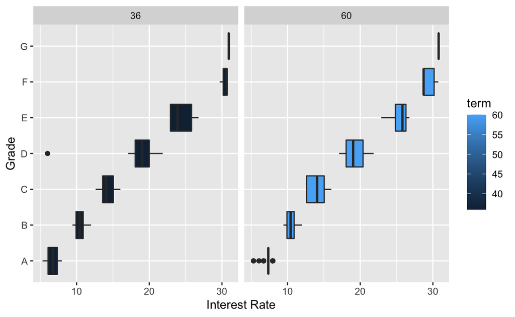

```r
ggplot(data_clean, aes(x =  interest_rate, y = grade , fill = term)) +
        geom_boxplot() +
        labs(x = 'Interest Rate' , y = 'Grade') +
  facet_wrap(~ term)
```

We find that as the value of Grade increases from A to G, the interest rate also increases linearly. Therefore, a linear relationship between the Grade and Interest Rate is seen, which is applicable for both terms of 36 months and 60 months. Which is in compliance with the fact that Higher-grade loans (i.e. A,B,C) indicate better credit and lower risk while lower grade loans (i.e. E, F, G) indicate the opposite, and thus lower interest rate for Higher-grade loans and higher interest rates for lower grade loans.

**Loan Amount VS Grade highlighting Sub Grade on term of loan**

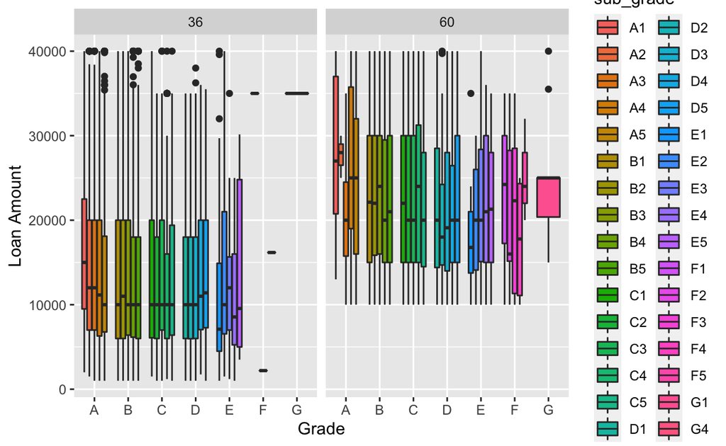

```r
ggplot(data_clean, aes(x = grade , y = loan_amount , fill = sub_grade)) +
        geom_boxplot() +
        labs(y = 'Loan Amount' , x = 'Grade') +
  facet_wrap(~ term)
```

**State VS Percentage of Loans**

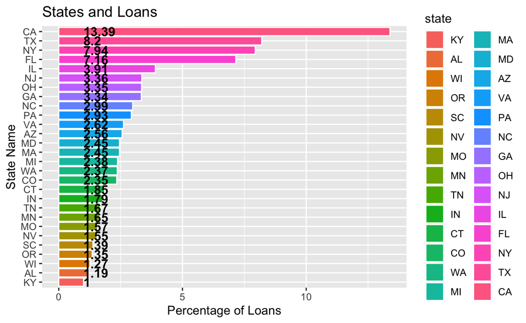

```r
data_clean %>%
  group_by(state) %>%
  summarise(CountLoanPurpose = n() ) %>%
  mutate(percentage = (CountLoanPurpose/sum(CountLoanPurpose) ) *100 ) %>%
  mutate(state = reorder(state, percentage)) %>%
  arrange(desc(percentage)) %>%
  filter(percentage > 1) %>%

  ggplot(aes(x = state, y = percentage, fill=state)) +
  geom_bar(stat='identity', colour="white") +
  geom_text(aes(x = state, y = 1, label = paste0(round(percentage,2),sep="")),
            hjust=0, vjust=.5, size = 4, colour = 'black',
            fontface = 'bold') +
  labs(x = 'State Name', y = 'Percentage of Loans', title = 'States and Loans') +
  coord_flip()
```

**Purpose VS Loan Amount on Type of Application**

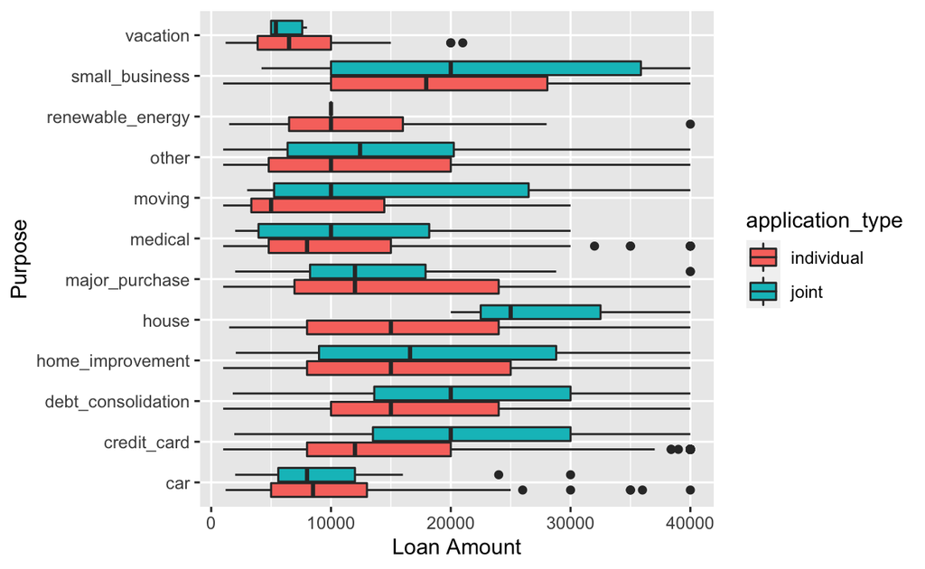

```r
ggplot(data_clean, aes(y =  loan_purpose, x = loan_amount, fill = application_type)) +
        geom_boxplot() +
        labs(x = 'Loan Amount' , y = 'Purpose')
```

The relationship between the purpose and loan amount is observed here, and we can also see the type of application for the loan here. It is seen that a joint application type corresponds to higher loan amount, and this relationship is extremely visible for purposes like Small Businesses and House.

# Reflection

I feel that a plot between the total annual income and the loan amount will add to the analysis as it depicts the borrowing capacity of the borrower based on their annual income. A plot between the Purpose and Loan Amount on Type of income source will also enhance the analysis as it gives important insight as well.

I strongly feel that these plots are easier to understand and portray a clear picture delienating the relationships between different variables, and would be easily understood by a naive user.

The dataset can not be used to answer questions on the monthly payments made by the borrower and if the borrower was late or not for these payments.